# Chapter 2 - Regression and model validation

- Did the dataCamp exercises.

# Wrangling code:

```r
library(dplyr)
library(ggplot2)
library(GGally)
lrn14 <- read.table("http://www.helsinki.fi/~kvehkala/JYTmooc/JYTOPKYS3-
data.txt", sep="\t", header=TRUE)
dim(lrn14)
```

```
## [1] 183  60
```

```r
str(lrn14)
```

```
## 'data.frame':    183 obs. of  60 variables:
##  $ Aa      : int  3 2 4 4 3 4 4 3 2 3 ...
##  $ Ab      : int  1 2 1 2 2 2 1 1 1 2 ...
##  $ Ac      : int  2 2 1 3 2 1 2 2 2 1 ...
##  $ Ad      : int  1 2 1 2 1 1 2 1 1 1 ...
##  $ Ae      : int  1 1 1 1 2 1 1 1 1 1 ...
##  $ Af      : int  1 1 1 1 1 1 1 1 1 2 ...
##  $ ST01    : int  4 4 3 3 4 4 5 4 4 4 ...
##  $ SU02    : int  2 2 1 3 2 3 2 2 1 2 ...
##  $ D03     : int  4 4 4 4 5 5 4 4 5 4 ...
##  $ ST04    : int  4 4 4 4 3 4 2 5 5 4 ...
##  $ SU05    : int  2 4 2 3 4 3 2 4 2 4 ...
##  $ D06     : int  4 2 3 4 4 5 3 3 4 4 ...
##  $ D07     : int  4 3 4 4 4 5 4 4 5 4 ...
##  $ SU08    : int  3 4 1 2 3 4 4 2 4 2 ...
```

[output cut: 46 more lines]

- Reading the table from web and saving to lrn14. 183 rows/persons, 60 variables.

```r
deep_questions <- c("D03", "D11", "D19", "D27", "D07", "D14", "D22", "D30","D06",  "D15", "D23", "D31")
deep_columns <- select(lrn14, one_of(deep_questions))
deep <- rowMeans((deep_columns))
surface_questions <- c("SU02","SU10","SU18","SU26", "SU05","SU13","SU21","SU29","SU08","SU16","SU24","SU32")
surface_columns <- select(lrn14, one_of(surface_questions))
surf <- rowMeans(surface_columns)
strategic_questions <- c("ST01","ST09","ST17","ST25","ST04","ST12","ST20","ST28")
strategic_columns <- select(lrn14, one_of(strategic_questions))
stra <- rowMeans(strategic_columns)
```

- Taking courses(in deep, strategic…) and counting their means to create new combination variables.

```r
keep_columns <- c("gender","Age","Attitude", "Points")
learning2014 <- select(lrn14, one_of(keep_columns))
```

- Decide columns to take and retrieve all of them to “learning2014”
- Choosing the columns, creating new data frame learning2014 for analyzing.

```r
learning2014$deep <- deep
learning2014$stra <- stra
learning2014$surf <- surf
learning2014 <-filter(learning2014, Points>0)
str(learning2014)
```

```
## 'data.frame':    166 obs. of  7 variables:
##  $ gender  : Factor w/ 2 levels "F","M": 1 2 1 2 2 1 2 1 2 1 ...
##  $ Age     : int  53 55 49 53 49 38 50 37 37 42 ...
##  $ Attitude: int  37 31 25 35 37 38 35 29 38 21 ...
##  $ Points  : int  25 12 24 10 22 21 21 31 24 26 ...
##  $ deep    : num  3.58 2.92 3.5 3.5 3.67 ...
##  $ stra    : num  3.38 2.75 3.62 3.12 3.62 ...
##  $ surf    : num  2.58 3.17 2.25 2.25 2.83 ...
```

```r
dim(learning2014)
```

```
## [1] 166   7
```

- Insert compilation variables and filtering zero-pointers. Now we have Learning table with keep columns and combination columns.

```r
write.table(learning2014, file = "data/learning2014.txt", row.names = TRUE)

new_table <- read.table(file = "data/learning2014.txt", header=TRUE)
dim(new_table)
```

```
## [1] 166   7
```

```r
str(new_table)
```

```
## 'data.frame':    166 obs. of  7 variables:
##  $ gender  : Factor w/ 2 levels "F","M": 1 2 1 2 2 1 2 1 2 1 ...
##  $ Age     : int  53 55 49 53 49 38 50 37 37 42 ...
##  $ Attitude: int  37 31 25 35 37 38 35 29 38 21 ...
##  $ Points  : int  25 12 24 10 22 21 21 31 24 26 ...
##  $ deep    : num  3.58 2.92 3.5 3.5 3.67 ...
##  $ stra    : num  3.38 2.75 3.62 3.12 3.62 ...
##  $ surf    : num  2.58 3.17 2.25 2.25 2.83 ...
```

- Saving and loading from /data

# Analysis

2.1

```r
new_table <- read.table(file = "data/learning2014.txt", header=TRUE)
summary(new_table)
```

```
##  gender       Age           Attitude         Points           deep
##  F:110   Min.   :17.00   Min.   :14.00   Min.   : 7.00   Min.   :1.583
##  M: 56   1st Qu.:21.00   1st Qu.:26.00   1st Qu.:19.00   1st Qu.:3.333
##          Median :22.00   Median :32.00   Median :23.00   Median :3.667
##          Mean   :25.51   Mean   :31.43   Mean   :22.72   Mean   :3.680
##          3rd Qu.:27.00   3rd Qu.:37.00   3rd Qu.:27.75   3rd Qu.:4.083
##          Max.   :55.00   Max.   :50.00   Max.   :33.00   Max.   :4.917
##       stra            surf
##  Min.   :1.250   Min.   :1.583
##  1st Qu.:2.625   1st Qu.:2.417
##  Median :3.188   Median :2.833
##  Mean   :3.121   Mean   :2.787
##  3rd Qu.:3.625   3rd Qu.:3.167
##  Max.   :5.000   Max.   :4.333
```

- The data contains study information on 166 individuals, with 7 variables: Age(years), gender (F/M), Attitude, points, deep, stra and surf.
- Attitude is mean of answers on multiple questions measuring students attitude towards statistics.
- Deep, stra and surf are means of multiple questions measuring these subjects.
- Points is exam points.

2.2

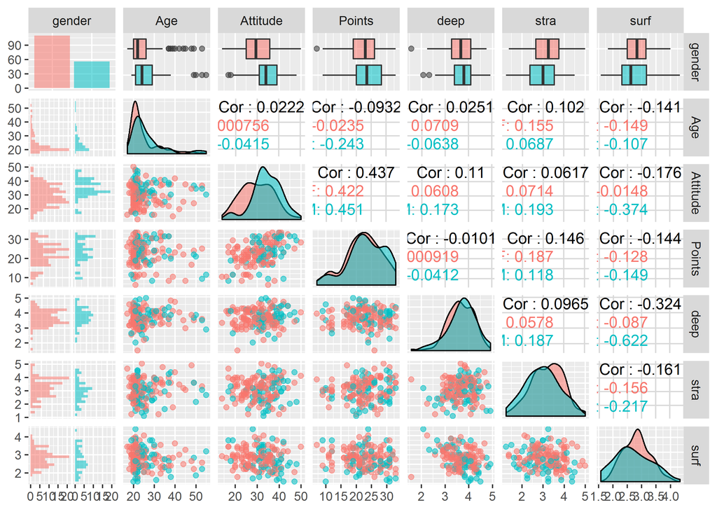

```r
p <- ggpairs(new_table, mapping = aes(col=gender, alpha=0.3), lower = list(combo = wrap("facethist", bins = 20)))
p
```

- Creates the plot of new_table and prints it.

```r
table(cut(new_table$Age, breaks = seq(15,55,by=10)))
```

```
##
## (15,25] (25,35] (35,45] (45,55]
##     116      32      11       7
```

```r
table(new_table$gender, cut(new_table$Attitude, breaks = seq(1,56,by=5)))
```

```
##
##     (1,6] (6,11] (11,16] (16,21] (21,26] (26,31] (31,36] (36,41] (41,46]
##   F     0      0       2      15      23      22      26      17       3
##   M     0      0       0       3       2      11      17      17       4
##
##     (46,51] (51,56]
##   F       2       0
##   M       2       0
```

2.3

```r
my_model <- lm(Points ~ Attitude + stra + surf, data = new_table)
summary(my_model)
```

```
##
## Call:
## lm(formula = Points ~ Attitude + stra + surf, data = new_table)
##
## Residuals:
##      Min       1Q   Median       3Q      Max
## -17.1550  -3.4346   0.5156   3.6401  10.8952
##
## Coefficients:
##             Estimate Std. Error t value Pr(>|t|)
## (Intercept) 11.01711    3.68375   2.991  0.00322 **
## Attitude     0.33952    0.05741   5.913 1.93e-08 ***
## stra         0.85313    0.54159   1.575  0.11716
## surf        -0.58607    0.80138  -0.731  0.46563
## ---
## Signif. codes:  0 '***' 0.001 '**' 0.01 '*' 0.05 '.' 0.1 ' ' 1
##
## Residual standard error: 5.296 on 162 degrees of freedom
## Multiple R-squared:  0.2074, Adjusted R-squared:  0.1927
## F-statistic: 14.13 on 3 and 162 DF,  p-value: 3.156e-08
```

- Attitude having 0.34 regression to points is significant, attitude has ***
- Multiple R-squared: 0.21 and 0.34 regression.
- Dropping stra and surf because those are not relevant.

```r
my_model <- lm(Points ~ Attitude, data = new_table)
```

2.4

```r
summary(my_model)
```

```
##
## Call:
## lm(formula = Points ~ Attitude, data = new_table)
##
## Residuals:
##      Min       1Q   Median       3Q      Max
## -16.9763  -3.2119   0.4339   4.1534  10.6645
##
## Coefficients:
##             Estimate Std. Error t value Pr(>|t|)
## (Intercept) 11.63715    1.83035   6.358 1.95e-09 ***
## Attitude     0.35255    0.05674   6.214 4.12e-09 ***
## ---
## Signif. codes:  0 '***' 0.001 '**' 0.01 '*' 0.05 '.' 0.1 ' ' 1
##
## Residual standard error: 5.32 on 164 degrees of freedom
## Multiple R-squared:  0.1906, Adjusted R-squared:  0.1856
## F-statistic: 38.61 on 1 and 164 DF,  p-value: 4.119e-09
```

- Multiple R-squared: 0.19 and 0.35 regression. predictors explain 19% of variance. 1 point in attitude raises exam points by 0.353 on average.

```r
my_model <- lm(Points ~ Attitude, data = new_table)
summary(my_model)
```

```
##
## Call:
## lm(formula = Points ~ Attitude, data = new_table)
##
## Residuals:
##      Min       1Q   Median       3Q      Max
## -16.9763  -3.2119   0.4339   4.1534  10.6645
##
## Coefficients:
##             Estimate Std. Error t value Pr(>|t|)
## (Intercept) 11.63715    1.83035   6.358 1.95e-09 ***
## Attitude     0.35255    0.05674   6.214 4.12e-09 ***
## ---
## Signif. codes:  0 '***' 0.001 '**' 0.01 '*' 0.05 '.' 0.1 ' ' 1
##
## Residual standard error: 5.32 on 164 degrees of freedom
## Multiple R-squared:  0.1906, Adjusted R-squared:  0.1856
## F-statistic: 38.61 on 1 and 164 DF,  p-value: 4.119e-09
```

2.5 - Assumptions of linear regression models:

- The errors are normally distributed
- The errors are not correlated
- The errors have constant variance
- The size of a given error does not depend on the explanatory variables

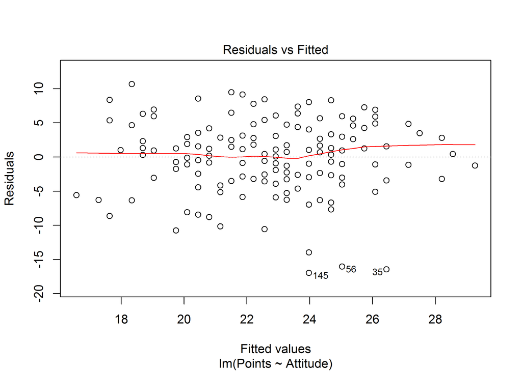

```r
plot(my_model, which =c(1))
```

- Residual vs fitted. Tells if there are patterns, patterns mean problem with the assumption. If there would be bigger residual on bigger values, the assumption(my_model) would need to be corrected. Residuals seem to be scattered evenly(variance seems constant).

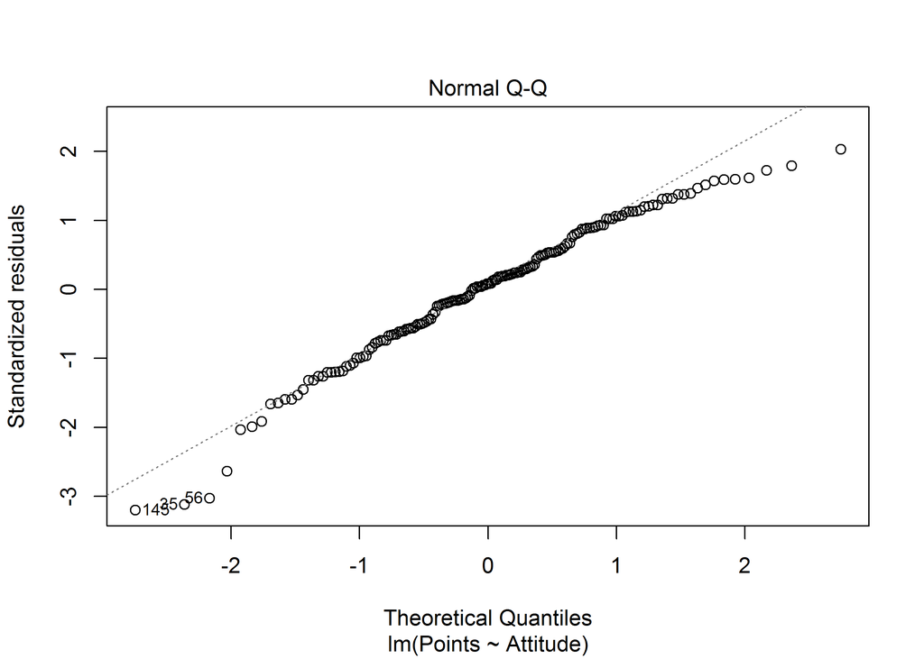

```r
plot(my_model, which =c(2))
```

- The Q-Q-plot most of the points are on line with little mix in the ends. Shows the error assumption. Seems good enough,

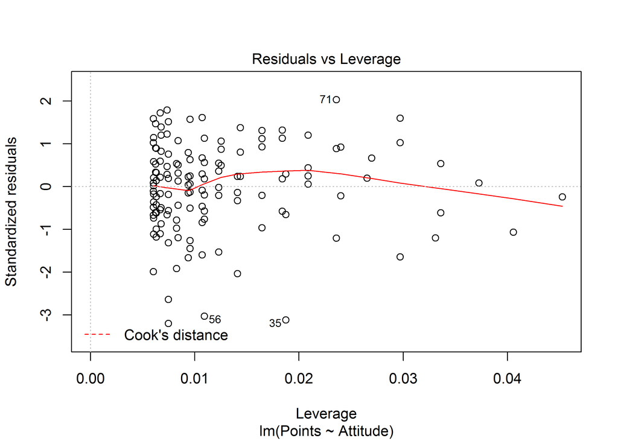

```r
plot(my_model, which =c(5))
```

- Tells if there are influentical cases in the model. if there are cases on top right or bottom right, those would strongly influence the results.